# Motivate Bikeshare Data Analysis

Josh Miller

2026-03-01

# EXPLORE BIKESHARE DATA

In this project I will be using R to analyze Motivate bikeshare data from three locations in the United States:

- Washington, D.C.
- Chicago
- New York City

My analysis will answer three questions:

- What are the busiest stations in each city?
- Which city has the highest percentage of rides by subscribers?
- What gender takes the most trips? Longest average trip?

```r
# import plotting library
library(ggplot2)

# read in data sets
bs.wdc <- read.csv('../Datasets/washington.csv')
bs.chi <- read.csv('../Datasets/chicago.csv')
bs.nyc <- read.csv('../Datasets/new-york-city.csv')
```

## Question 1: What are the busiest stations in each city?

The busiest stations in each city will be the one that shows up the most as either a start or end location, so we will be adding the counts of both columns for each station and find the top ten values for each city. I will write a function to calculate this so I don’t have to write the same code block three times.

```r
busiest_stations <- function(bs.data){

# First I will read in the two station name columns into tables, which will
# produce counts of how many times all the stations have been recorded as
# either start (departure) or end (arrival) stations.

  station.start <- table(bs.data$Start.Station)
  station.end <- table(bs.data$End.Station)

# Next I want to setup data frames for the start and end station counts,
# because they are easier to work with when we need to add rows or columns
# later on (which we will). The count values in the tables above will be
# stored as vectors, and the names of each station from each table will be
# stored as well, with both variables forming the two columns in each data
# frame - name of the station, and how many times it was arrived at /
# departed from.

  freq.start <- c(station.start)
  names(freq.start) <- NULL
  station.start.df <- data.frame(
    station = names(station.start),
    departures = freq.start
  )

  freq.end <- c(station.end)
  names(freq.end) <- NULL
  station.end.df <- data.frame(
    station = names(station.end),
    arrivals = freq.end
  )

# The main reason I put these into data frames is that if the original tables
# were bound, I found that there is a misaligned section of indices that
# caused some values to be assigned to the wrong stations because some
# stations are only ever left from or arrived to, so they don't show up in
# the frequency tables and values get shifted in the merge. My solution
# is to write a couple of loops that will find stations that were either only
# departed from or arrived at, and add those to the other data frame with
# values of 0 manually assigned, which will allow us to align our values
# correctly and easily calculate total traffic values for each station.

  unmatched.start <- list()
  unmatched.end <- list()
  station.start.df.full <- station.start.df
  station.end.df.full <- station.end.df

  for (n in station.start.df$station){
    if (!(n %in% station.end.df$station)){
      cat("Unmatched: ", n, "\n")
      unmatched.start <- append(unmatched.start,
                                c(which(station.start.df$station == n)))
    }
  }

  for (n in station.end.df$station){
    if (!(n %in% station.start.df$station)){
      cat("Unmatched: ", n, "\n")
      unmatched.end <- append(unmatched.end,
                              c(which(station.end.df$station == n)))
    }
  }

  for(s in unmatched.start){
    new.row.start <- data.frame(station = station.end.df$station[s],
                                departures = 0)
    station.start.df.full <- rbind(station.start.df.full, new.row.start)
  }

  for (e in unmatched.end){
    new.row.end <- data.frame(station = station.start.df$station[e],
                              arrivals = 0)
    station.end.df.full <- rbind(station.end.df.full, new.row.end)
  }

# The data frames are complete sets now, so we can sort them alphabetically
# and merge so that each row shows a station name, how many times it was
# departed from, and how many times it was arrived at.

  station.start.df.full <- sort_by.data.frame(station.start.df.full,
                                              station.start.df.full$station)

  station.end.df.full <- sort_by.data.frame(station.end.df.full,
                                            station.end.df.full$station)

  station.busy <- merge(station.start.df.full, station.end.df.full,
                        by = 'station')

# Then we can add a total column to show total traffic values for each station.

  total.col <- data.frame(total = station.busy$departures +
                                  station.busy$arrivals)

  station.busy <- cbind.data.frame(station.busy, total.col)

# Our busiest stations will be the ones with the highest values in the total
# column, so let's descending sort the data frame by that column.

  station.busiest <- sort_by.data.frame(station.busy, station.busy$total,
                                        decreasing=TRUE)

# In practicing plot production on this data set, I found that the station
# names, which are often cross streets, were quite long and made the bottom
# margin of the plot look weird, or the names would run off the side/bottom
# of the plot entirely. To help remedy this, I inserted newlines after any
# slashes or ampersands in the station names. The other fixes lie in the
# plotting function.

  station.busiest$station <- gsub("/", "/\n", station.busiest$station)
  station.busiest$station <- gsub("&", "&\n", station.busiest$station)

# Now we can return the cleaned and completed data frame for the city named
# in the parameters of this function.

  return(station.busiest)
}
```

I will also write a function to plot the top ten busiest stations in each city. This function will take the data frame returned by the above function, a string to tile the plot with, and outline and fill colors for the bar graphs it produces. On top of the bar plot, I am adding line plots to show how departures and arrivals contribute to each station’s total traffic, which hopefully will show some interesting and potentially insightful gaps in flow at some stations.

```r
busiest_stations_plot <- function(bs.busiest.data, plot.name,
                                  outline_color, fill_color){
  ggplot(
    aes(x = reorder(station, total, decreasing=TRUE), # reordering bars to hi-lo
        y = total),
    data = head(bs.busiest.data, 10) # only want top ten results to show
    ) +
    geom_col(
      color = outline_color,
      fill = fill_color
    ) +
    xlab(
      "Station Location"
    ) +
    ylab(
      "Total Traffic"
    ) +
    ggtitle(
      plot.name
    ) +
    theme(
      axis.text.x = element_text(
        angle = 50, # angle adjustment required to fit some station names
        hjust = 1,
        vjust = 1,
        family = 'mono', # most legible for angled text at this size
        face='bold'),
      plot.title = element_text(
        hjust = .5,
        family = 'mono',
        face = 'bold')
    ) +
    geom_line( # arrivals line plot
      aes(x = station, y = arrivals,
          group = 1, color = 'Arrivals'),
      data = head(bs.busiest.data, 10),
      linewidth = 1.5,
      linetype = 3
    ) +
    geom_line( # departures line plot
      aes(x = station, y = departures,
          group = 1, color = 'Departures'),
      data = head(bs.busiest.data, 10),
      linewidth = 1.5,
      linetype = 3
    ) +
    guides(
      color = guide_legend(
        title = "Type of Traffic"
      )
    )
}
```

Now let’s see what these data frames and plots can tell us. I used colors associated with each city’s flag to customize and differentiate the appearance of their plots. I will save the plots to my project folder after generating them as well, in case I want to put them in a different report later on.

### Washington, D.C.

```r
wdc.busiest <- busiest_stations(bs.wdc)
```

```
## Unmatched:  Columbus Ave & Gramercy Blvd
## Unmatched:  Broschart & Blackwell Rd
```

```r
wdc.plot <- busiest_stations_plot(wdc.busiest,
            "Busiest Motivate Bikeshare Stations - Washington, D.C.",
            '#E91436', '#FFFFFF')

head(wdc.busiest, 10)
```

```
##                                                       station departures arrivals total
## 210                         Columbus Circle /\n Union Station       5656     6048 11704
## 282                               Jefferson Dr &\n 14th St SW       5022     5218 10240
## 306                                          Lincoln Memorial       5043     5036 10079
## 321                    Massachusetts Ave &\n Dupont Circle NW       3946     4483  8429
## 50                                           15th &\n P St NW       3519     3733  7252
## 283                                        Jefferson Memorial       3514     3637  7151
## 423 Smithsonian-National Mall /\n Jefferson Dr &\n 12th St SW       3363     3599  6962
## 278             Henry Bacon Dr &\n Lincoln Memorial Circle NW       3121     3101  6222
## 141                                  4th St &\n Madison Dr NW       3011     2920  5931
## 37                                           14th &\n V St NW       2788     2958  5746
```

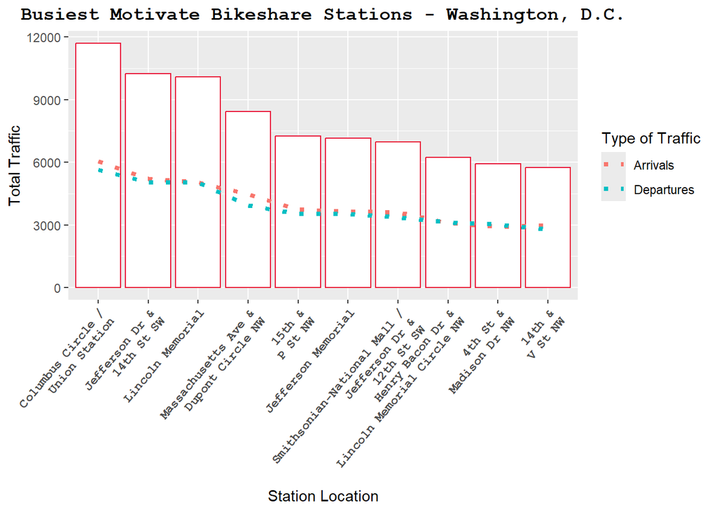

```r
wdc.plot
```

The busiest station in Washington, D.C. is at Columbus Circle / Union Station with almost 12,000 trips beginning or terminating there.

```r
ggsave('../Visualizations/Motivate-Washington_Busiest-Stations.png',
       plot=wdc.plot)
```

### Chicago

```r
chi.busiest <- busiest_stations(bs.chi)
```

```
## Unmatched:  Elizabeth St & 47th St
## Unmatched:  Exchange Ave & 79th St
## Unmatched:  Phillips Ave & 79th St
## Unmatched:  Racine Ave & 65th St
## Unmatched:  Calumet Ave & 71st St
## Unmatched:  Cicero Ave & Flournoy St
## Unmatched:  Halsted St & 59th St
## Unmatched:  Mason Ave & Madison St
## Unmatched:  Perry Ave & 69th St
## Unmatched:  Racine Ave & 61st St
## Unmatched:  South Chicago Ave & 83rd St
## Unmatched:  Woodlawn Ave & 75th St
```

```r
chi.plot <- busiest_stations_plot(chi.busiest,
            "Busiest Motivate Bikeshare Stations - Chicago",
            '#FF0000', '#B3DDF2')

head(chi.busiest, 10)
```

```
##                            station departures arrivals total
## 510      Streeter Dr &\n Grand Ave       6911     7512 14423
## 138 Clinton St &\n Washington Blvd       4306     4166  8472
## 296    Lake Shore Dr &\n Monroe St       4289     4016  8305
## 134      Clinton St &\n Madison St       3744     4014  7758
## 297   Lake Shore Dr &\n North Blvd       3348     3863  7211
## 512            Theater on the Lake       3317     3559  6876
## 77           Canal St &\n Adams St       3443     3367  6810
## 358        Michigan Ave &\n Oak St       2869     3054  5923
## 360 Michigan Ave &\n Washington St       2778     3023  5801
## 364                Millennium Park       2728     3036  5764
```

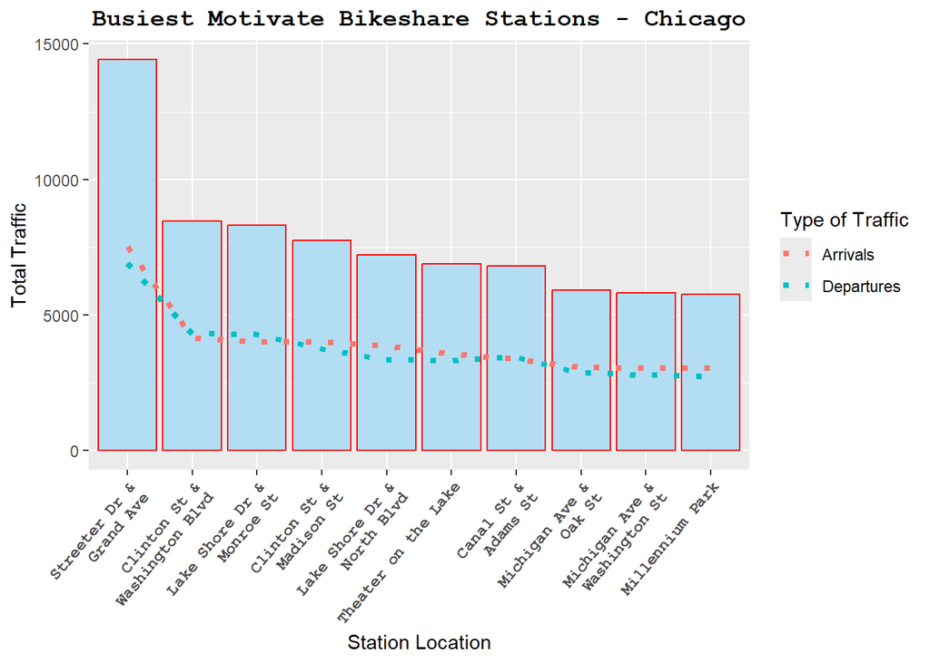

```r
chi.plot
```

The busiest station in Chicago is by far Streeter Dr & Grand Ave, with over 14,000 trips beginning or ending there.

```r
ggsave('../Visualizations/Motivate-Chicago_Busiest-Stations.png',
       plot=chi.plot)
```

### New York City

```r
nyc.busiest <- busiest_stations(bs.nyc)
```

```
## Unmatched:  LPI Facility
## Unmatched:  Paulus Hook
## Unmatched:  Van Vorst Park
```

```r
nyc.plot <- busiest_stations_plot(nyc.busiest,
            "Busiest Motivate Bikeshare Stations - New York City",
            '#FF6600', '#003585')

head(nyc.busiest, 10)
```

```
##                     station departures arrivals total
## 476   Pershing Square North       3069     3077  6146
## 115    Broadway &\n E 22 St       2082     2343  4425
## 233    E 17 St &\n Broadway       2089     2316  4405
## 567       W 21 St &\n 6 Ave       2019     2036  4055
## 635 West St &\n Chambers St       1968     1968  3936
## 564      W 20 St &\n 11 Ave       1743     1932  3675
## 66        8 Ave &\n W 31 St       1741     1828  3569
## 67        8 Ave &\n W 33 St       1701     1734  3435
## 582       W 38 St &\n 8 Ave       1497     1628  3125
## 585       W 41 St &\n 8 Ave       1604     1506  3110
```

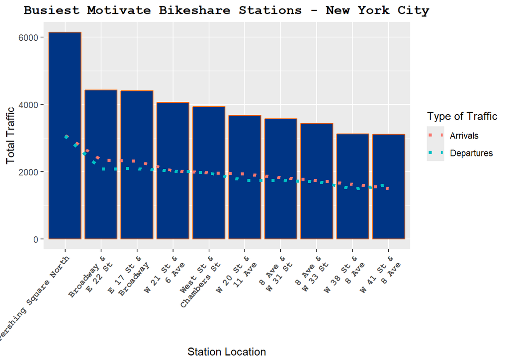

```r
nyc.plot
```

Finally, New York City’s busiest station, Pershing Square North, logs a little over 6,000 trip starts and ends.

```r
ggsave('../Visualizations/Motivate-NYC_Busiest-Stations.png',
       plot=nyc.plot)
```

## Question 2: Which city has the highest percentage of rides by subscribers?

In this section we will find the city with the highest proportion of rides completed by customers paying a regular subscription by finding the sub- scriber ratio in each city and comparing the three values. To start, I will put the city names and respective data sets into a list, so that we can easily iterate through the subscriber ratio calculation later.

```r
cities <- list(name = c('Washington, D.C.', 'Chicago', 'New York City'),
               bs.data = list(bs.wdc, bs.chi, bs.nyc))
```

Next, I will set up an empty data frame with the column names I wish to use.

```r
user.type.df <- data.frame(
  city = NULL,
  customers = NULL,
  subscribers = NULL,
  pct_customers = NULL,
  pct_subscribers = NULL
)
```

Here is a function I made to calculate the percent of riders. It takes the name of a city, its data set, and the data frame I built above as parameters. It will start by counting the number of each user type in a table, then use the values in that table to calculate the pct of rides by subscribed users. Finally, it will store the new row of data in the provided data frame and return the updated data frame.

```r
pct_rides_subbed <- function(city, bs.data, df){
  city.tbl <- table(bs.data$User.Type)
  pct.sub <- round(100 * (city.tbl[['Subscriber']] / nrow(bs.data)), digits=2)
  pct.cust <- 100 - pct.sub

  add.city <- data.frame(city = city,
                         customers = city.tbl[['Customer']],
                         subscribers = city.tbl[['Subscriber']],
                         pct_customers = pct.cust,
                         pct_subscribers = pct.sub)

  user.count.df <- rbind(df, add.city)

  return(user.count.df)
}
```

I will now use this function in a loop to add the three cities and their values to the data frame.

```r
for (i in c(1:lengths(cities)[['name']])){
  target.city <- cities$name[i]
  target.data <- cities$bs.data[[i]]
  user.type.df <- pct_rides_subbed(target.city, target.data, user.type.df)
}
```

The city with the most rides by subscribers will be the max value in the `pct_subscribers` column of the data frame. I will store the value and name of this result in their own variables to make printing the result easier.

```r
top.sub.pct <- max(user.type.df$pct_subscribers)

top.sub.city <- user.type.df$city[which(
                                    user.type.df$pct_subscribers == top.sub.pct
                                    )]

cat("City with highest percent of rides by subscribers: ", top.sub.city,
    " (", top.sub.pct, "%)", sep="")
```

```
## City with highest percent of rides by subscribers: New York City (89.72%)
```

Let’s make a plot to drive this result home visually.

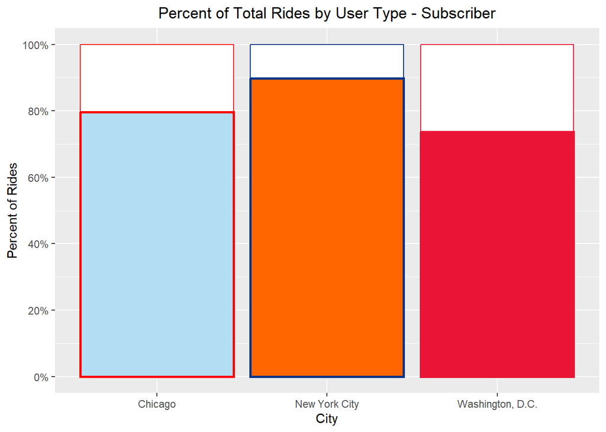

```r
pct.sub.plot <- ggplot(
  aes(x = city, y = pct_subscribers + pct_customers, fill = city, color = city),
  data = user.type.df) +
  geom_col(fill = "#FFFFFF") + # first plot layer will be a bar = 100%
  xlab("City") +
  scale_y_continuous(
    name = "Percent of Rides",
    breaks = (seq(0, 100, 20)),
                     labels = scales::label_percent(scale=1)
  ) +

  # manually setting color values to match city flags again
  scale_color_manual(values = c("Chicago" = "#FF0000",
                               "New York City" = "#003585",
                               "Washington, D.C." = "#E91436")) +
  scale_fill_manual(values = c("Chicago" = "#B3DDF2",
                               "New York City" = "#FF6600",
                               "Washington, D.C." = "#E91436")) +

  # adding plot layer to show percent of rides by subscribed users
  geom_col(aes(x = city, y = pct_subscribers, fill = city, color = city),
           data = user.type.df,
           linewidth = 1) +

  # legend is redundant
  theme(legend.position = "none",
        plot.title = element_text(hjust=.5)) +
  ggtitle("Percent of Total Rides by User Type - Subscriber")

pct.sub.plot
```

We can see that New York City has the highest ratio of rides by subscribers.

```r
ggsave('../Visualizations/Motivate_Percent-Rides-By-Subscriber.png',
       plot=pct.sub.plot)
```

## Question 3: What gender takes the most trips? Longest average trip?

This two-part question is answered using pretty simple analysis. Note this section only uses Chicago and New York City data, as they record user gender and Washington, D.C. does not.

```r
trips <- rbind(bs.chi, bs.nyc)
```

These tables include some empty Gender values, presumably some customers prefer not to share their gender in their account. We will filter the data to only include rows with complete gender information.

```r
trips <- subset(trips, (Gender == 'Male' | Gender == 'Female'))
```

The first part of question will just need a simple count of how many trips are recorded by each gender, which we can find by putting the Gender column of the full data into a table.

```r
trips.g <- table(trips$Gender)
```

Similar to before, I am storing the name of the gender and the count in separate variables to make writing my cat() statement easier.

```r
most.trips.gender <- names(trips.g)[which.max(trips.g)]
most.trips.amt <- trips.g[which.max(trips.g)]

cat("Gender which takes the most trips: ", most.trips.gender, " (",
    most.trips.amt, ")", sep="")
```

```
## Gender which takes the most trips: Male (385198)
```

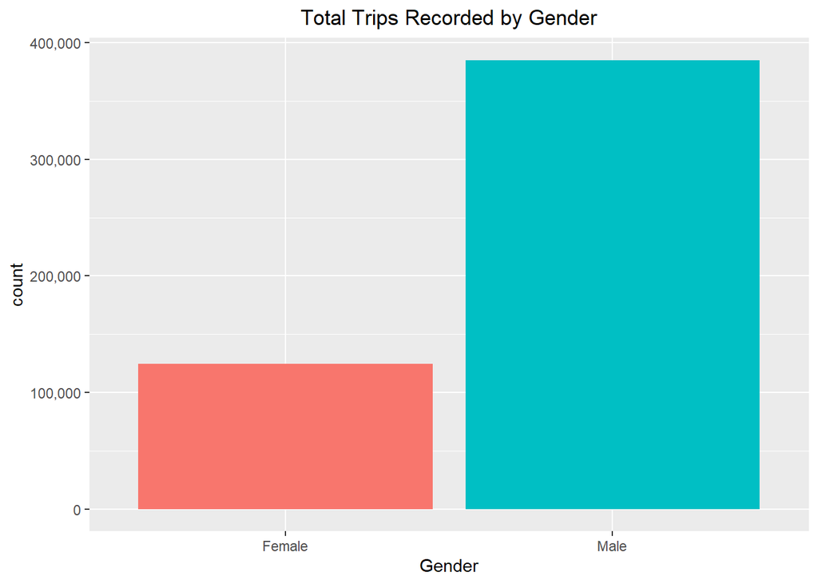

```r
most.trips.plot <- ggplot(aes(x=Gender, fill = Gender),
                     data=trips) +
  geom_bar() +
  ggtitle("Total Trips Recorded by Gender") +
  scale_y_continuous(labels = scales::comma) +
  theme(legend.position = 'none',
        plot.title = element_text(hjust = 0.5))

most.trips.plot
```

The bar graph shows that it wasn’t very close, male users recorded significantly more trips than female users. For the second part of this question, since we need both gender and trip duration data, and we are looking for an average, I’ll use a by() statement to filter our data. I am going to use median as my measure of middle here because, as will be seen in the box plot later, both genders have several outliers dragging their mean values up. Here’s what the summary for this data looks to give an idea:

```r
by(trips[,"Trip.Duration"], trips[,"Gender"], summary)
```

```
## trips[, "Gender"]: Female
##     Min.  1st Qu.   Median     Mean  3rd Qu.     Max.
##     60.0    400.0    651.0    837.9   1047.0 332970.0
## -----------------------------------------------------------------------------------
## trips[, "Gender"]: Male
##      Min.   1st Qu.    Median      Mean   3rd Qu.      Max.
##      60.0     339.0     545.0     726.3     887.0 2155775.0
```

Those are some incredibly high max values, and the mean is ~200 seconds higher than the median in both cases. I trust the median to be a better fit.

```r
trips.d.med <- by(trips[,"Trip.Duration"], trips[,"Gender"], median)
```

Again, storing name of gender + value separately.

```r
longest.trips.gender <- names(trips.d.med)[which.max(trips.d.med)]
longest.trips.amt <- max(trips.d.med)

cat("Gender which takes the longest average trip: ", longest.trips.gender, " (",
    longest.trips.amt, " seconds)", sep="")
```

```
## Gender which takes the longest average trip: Female (651 seconds)
```

Let’s look at the boxplots for these results. I brought the y limit of the plot in to trips lasting 40 minutes, because that’s what cuts out enough outliers that the box plot results are actually legible.

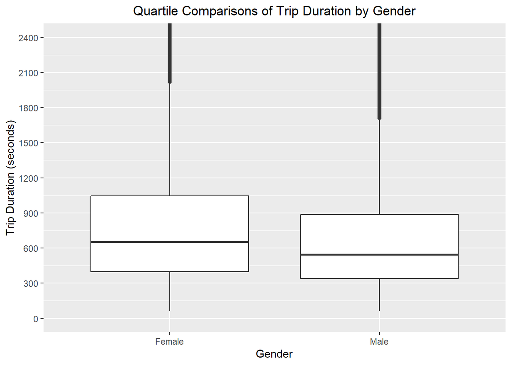

```r
longest.trips.boxplot <- ggplot(aes(x=Gender, y = Trip.Duration),
                        data=trips) +
  geom_boxplot() +
  scale_y_continuous(breaks = seq(0, 2400, 300)) +
  coord_cartesian(ylim = c(0, 2400)) +
  ggtitle("Quartile Comparisons of Trip Duration by Gender") +
  ylab("Trip Duration (seconds)") +
  theme(plot.title = element_text(hjust = 0.5))

longest.trips.boxplot
```

We can see all the quartiles for female users are higher than for male, so it looks like our results printed earlier check out. I also want to look at histograms for each gender to get a real sense of scale for how many of these longer trips female users are taking compared to male users. I’ll be overlaying the medians for each as vertical lines to add context too.

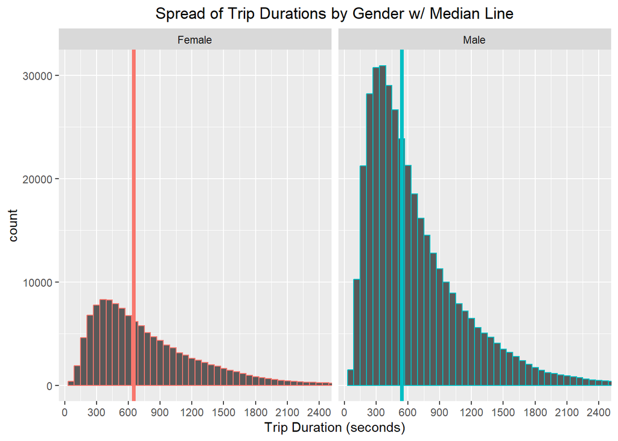

```r
longest.trips.hist <- ggplot(aes(x=Trip.Duration, color = Gender),
                             data=trips) +
  geom_histogram(binwidth = 60, position = "dodge") +
  scale_x_continuous(breaks = (seq(0, 2400, 300))) +
  coord_cartesian(xlim = c(60,2400)) +
  xlab("Trip Duration (seconds)") +
  ggtitle("Spread of Trip Durations by Gender w/ Median Line") +
  geom_vline(aes(xintercept = trips.d.med["Male"]),
             data = subset(trips, Gender=="Male"),
             color = '#00bfc4',
             linewidth = 1.5) +
  geom_vline(aes(xintercept = trips.d.med["Female"]),
             data = subset(trips, Gender=="Female"),
             color = '#f8766d',
             linewidth = 1.5) +
  facet_wrap(~Gender) +
  theme(legend.position = 'none',
        plot.title = element_text(hjust = 0.5))

longest.trips.hist
```

These right-skewed histograms really help illustrate that the majority of trips are 10 minutes long or less, and because male users make more trips by a significant amount, it makes sense that their median (and mean) are lower than those of female users.

```r
ggsave('../Visualizations/Motivate_Gender-Trip-Count.png',
       plot = most.trips.plot)
ggsave('../Visualizations/Motivate_Gender-Trip-Duration_BP.png',
       plot = longest.trips.boxplot)
ggsave('../Visualizations/Motivate_Gender-Trip-Duration_Hist.png',
       plot = longest.trips.hist)
```